# Red Dragon AI Course Assignment

## March 2020

### Introduction

The Deep Learning overview course offered by Red Dragon covered basic topics including Feed-Forward Neural Networks, as well as the basics of sequence and Convolutional Neural Network (CNN) architectures. As part of the course requirements, an assignment has to be submitted to demonstrate the attendees' understanding of the content covered during the course.

Inspired by [Karpathy's blog post](http://karpathy.github.io/2015/10/25/selfie/), my objective is to train a CNN model to predict the score indicating how popular a selfie image would be. For this project, the CNN model incorporates residual connections to allow the gradients to "flow" across the deep network. This "flow" arises from the general form of the Residual Network (ResNet), which is given by \begin{equation} y = z + f(z), \end{equation} with a derivative of \begin{equation} \frac{dy}{dz} = 1 + \frac{df}{dz}. \end{equation} By the chain rule, we get \begin{align*} \frac{dy}{dx} &= \frac{dy}{dz_3} \frac{dz_3}{dz_2} \frac{dz_2}{dz_1} \frac{dz_1}{dx}\\ &= \left(1 + \frac{df}{dz_3}\right) \left(1 + \frac{df}{dz_2}\right) \left(1 + \frac{df}{dz_1}\right) \frac{dz_1}{dx}, \end{align*} and hence, it can be observed that the gradient of $\displaystyle \frac{dy}{dx}$ has a component which depends directly on the gradient of the first layer $\displaystyle \frac{dz_1}{dx}$, allowing the gradient to "flow" from the input to the output layer. This "flow" has the effect of stabilising the overall training of the deep network. ResNets also have the indirect benefit of preventing the gradient from vanishing. This occurs when $\displaystyle \frac{dz_{k+1}}{dz_k}$ is small for all layers $k \geq 1$. To further stabilise the model, the model also applies Batch Normalisation. In addition, to mitigate the issue of the ReLU gradient saturating to 0 in the negative region (and resulting in no further updates to the weights in the subsequent iterations), Leaky ReLU was used as the activation function instead.

```python
import numpy as np
import pandas as pd
import matplotlib.pyplot as plt
import matplotlib.image as mpimg

# Define some functions for easy processing. #
def get_age_category(tmp_row):
    if tmp_row["baby"] == 1:
        return "baby"
    elif tmp_row["child"] == 1:
        return "child"
    elif tmp_row["teenager"] == 1:
        return "teenager"
    elif tmp_row["youth"] == 1:
        return "youth"
    elif tmp_row["middle_age"] == 1:
        return "middle_age"
    elif tmp_row["senior"] == 1:
        return "senior"
    else:
        return "unknown"

def get_gender(tmp_row):
    if tmp_row["is_female"] == 0:
        return "male"
    elif tmp_row["is_female"] == 1:
        return "female"
    else:
        return "unknown"
```

### Exploring the Selfie Dataset

The Selfie dataset is a set of 46,836 selfie images extracted from Instagram (to be confirmed) with a total of 36 attributes like age category (child or youth or middle age etc), gender (male or female), lighting conditions (harsh or dim lighting), which was submitted to the Proceedings of the 23rd Annual ACM Conference on Multimedia Conference in 2015. This dataset was made available for research purposes, with each image resized to 306 by 306 pixels.

```python
# Load the Selfie dataset. #
tmp_path = "C:/Users/admin/Desktop/Data/Selfie-dataset/"
tmp_selfie_df = pd.read_csv(tmp_path + "selfie_dataset_annotations.csv")

# Do some simple cleaning. #
tmp_selfie_df["gender"] = [get_gender(
    tmp_selfie_df.iloc[x]) for x in range(len(tmp_selfie_df))]
tmp_selfie_df["age_category"] = [get_age_category(
    tmp_selfie_df.iloc[x]) for x in range(len(tmp_selfie_df))]

# Display the DataFrame. #
tmp_selfie_df[["filename", "score", "gender", "age_category"]].head()
```

|  | filename | score | gender | age_category |
| --- | --- | --- | --- | --- |
| 0 | C:/Users/admin/Desktop/Data/Selfie-dataset/ima... | 3.901 | female | youth |
| 1 | C:/Users/admin/Desktop/Data/Selfie-dataset/ima... | 4.385 | female | unknown |
| 2 | C:/Users/admin/Desktop/Data/Selfie-dataset/ima... | 4.243 | female | teenager |
| 3 | C:/Users/admin/Desktop/Data/Selfie-dataset/ima... | 4.169 | male | teenager |
| 4 | C:/Users/admin/Desktop/Data/Selfie-dataset/ima... | 3.873 | female | middle_age |

Grouping by its attributes, it can be observed that the data is generally imbalanced, with almost 3 times as many females as males. Youth and teenagers also tend to be more prevalent in this dataset. Despite that, the mean scores of males to females and across the different age categories do not show any observable differences. Due to time constraints, I did not test whether the difference in score is statistically significant nor did any further changes to the CNN model to reduce the effect of this bias. However, I would like to caution readers of the possibility of the model displaying biasness due to the imbalanced nature of the dataset.

One thing that caught my attention was my realisation that the mean scores of children's and babies' selfies were the lowest amongst all the age categories available. I had always thought that pictures showing kids and babies would garner better scores since they are so cute, but on further thought, perhaps this is not surprising since babies most probably can't take selfies (or for that matter, most babies probably don't know how to use a phone).

```python
tmp_group_gender = pd.DataFrame(
    [(x, len(y), np.mean(y["score"])) for \
     x, y in tmp_selfie_df.groupby(["gender"])],
    columns = ["gender", "count", "mean_score"])

# Display the results. #
tmp_group_gender.sort_values(["count"], ascending=False).head()
```

|  | gender | count | mean_score |
| --- | --- | --- | --- |
| 0 | female | 33655 | 4.415638 |
| 1 | male | 13181 | 4.267206 |

```python
tmp_group_age = pd.DataFrame(
    [(x, len(y), np.mean(y["score"])) for \
     x, y in tmp_selfie_df.groupby(["age_category"])],
    columns = ["age_category", "count", "mean_score"])

# Display the results. #
tmp_group_age.sort_values(["count"], ascending=False).head(7)
```

|  | age_category | count | mean_score |
| --- | --- | --- | --- |
| 6 | youth | 31630 | 4.394028 |
| 5 | unknown | 6807 | 4.316122 |
| 4 | teenager | 6274 | 4.365037 |
| 2 | middle_age | 1118 | 4.310763 |
| 1 | child | 796 | 4.278460 |
| 0 | baby | 196 | 4.155434 |
| 3 | senior | 15 | 4.371667 |

Some examples of the selfies in the dataset and their corresponding attributes are shown below. As the images show, and as Karpathy's blog had also mentioned, there are some factors which could possibly affect the scores but are not recorded. For example, the lighting of some images might be too bright, while some might be in grey scale.

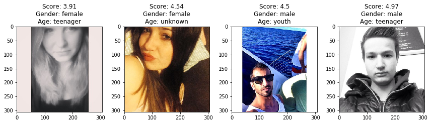

```python
# Randomly sample some images to display. #
fig, ax = plt.subplots(ncols=4, figsize=(12, 12))

tmp_idx = np.random.choice(len(tmp_selfie_df), size=4, replace=False)
n_image = 0
for row in ax:
    tmp_row = tmp_selfie_df.iloc[tmp_idx[n_image]]
    tmp_img = mpimg.imread(tmp_row["filename"])
    n_image += 1

    tmp_title = "Score: " + str(round(tmp_row["score"], 2)) + "\n"
    tmp_title += "Gender: " + str(tmp_row["gender"]) + "\n"
    tmp_title += "Age: " + str(tmp_row["age_category"])
    row.imshow(tmp_img)
    row.set(title=tmp_title)
plt.tight_layout()
```

### Convolutional Neural Network (CNN) Model Architecture

```python
tmp_model_params = "C:/Users/admin/Desktop/Data/Selfie-dataset/selfie_model_params.txt"
with open(tmp_model_params, "rb") as tmp_file_read:
    for tmp_line in tmp_file_read.readlines():
        print(tmp_line.decode("ascii").replace("\n", ""))
```

```
Model: "model"
_________________________________________________________________
Layer (type)                 Output Shape              Param #
=================================================================
image_inputs (InputLayer)    [(None, 150, 150, 3)]     0
_________________________________________________________________
block1_cnn_1 (Conv2D)        (None, 75, 75, 16)        1216
_________________________________________________________________
batch_normalization (BatchNo (None, 75, 75, 16)        64
_________________________________________________________________
leaky_re_lu (LeakyReLU)      (None, 75, 75, 16)        0
_________________________________________________________________
block1_cnn2 (Conv2D)         (None, 75, 75, 16)        2320
_________________________________________________________________
batch_normalization_1 (Batch (None, 75, 75, 16)        64
_________________________________________________________________
leaky_re_lu_1 (LeakyReLU)    (None, 75, 75, 16)        0
_________________________________________________________________
block2_cnn_1 (Conv2D)        (None, 75, 75, 16)        2320
_________________________________________________________________
batch_normalization_2 (Batch (None, 75, 75, 16)        64
_________________________________________________________________
leaky_re_lu_2 (LeakyReLU)    (None, 75, 75, 16)        0
_________________________________________________________________
block2_cnn2 (Conv2D)         (None, 75, 75, 16)        2320
_________________________________________________________________
batch_normalization_3 (Batch (None, 75, 75, 16)        64
_________________________________________________________________
leaky_re_lu_3 (LeakyReLU)    (None, 75, 75, 16)        0
_________________________________________________________________
block3_cnn_1 (Conv2D)        (None, 75, 75, 16)        2320
_________________________________________________________________
batch_normalization_4 (Batch (None, 75, 75, 16)        64
_________________________________________________________________
leaky_re_lu_4 (LeakyReLU)    (None, 75, 75, 16)        0
_________________________________________________________________
block3_cnn2 (Conv2D)         (None, 75, 75, 16)        2320
_________________________________________________________________
batch_normalization_5 (Batch (None, 75, 75, 16)        64
_________________________________________________________________
```

[output cut: 181 more lines]

```
_________________________________________________________________
average_pooling2d (AveragePo (None, 1, 1, 512)         0
_________________________________________________________________
flatten (Flatten)            (None, 512)               0
_________________________________________________________________
linear1 (Dense)              (None, 128)               65664
_________________________________________________________________
linear2 (Dense)              (None, 32)                4128
_________________________________________________________________
outputs (Dense)              (None, 1)                 33
=================================================================
Total params: 17,397,393
Trainable params: 17,385,297
Non-trainable params: 12,096
_________________________________________________________________
```

### Training the Network

To train the network, I applied a batch size of 32 and a learning rate of $10^{-3}$ and a decay rate of 0.90 after every epoch. The Adam Optimizer with the default beta values and a gradient clipping norm of 2.0 was applied. The train-validation split was 70\% to 20\%, with the remaining images used as the test dataset. After every epoch, the Mean Absolute Error of the validation dataset was computed to identify if early stopping is required. In this project, the model was trained over 20 epochs and no over-fitting was observed over the duration of the training in Fig. 1. The Mean Absolute Error on the test dataset is 0.386.

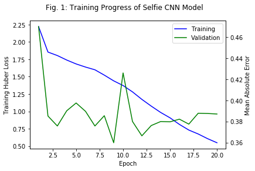

```python
train_progress = pd.read_csv(
    "C:/Users/admin/Desktop/TF_Models/selfie_model/selfie_losses.csv")

fig, ax1 = plt.subplots()
ax1.plot(train_progress["epoch"], train_progress["train_huber_loss"], color="b")
ax1.set(xlabel="Epoch", ylabel="Training Huber Loss")

ax2 = ax1.twinx()
ax2.plot(train_progress["epoch"], train_progress["valid_mae"], color="g")
ax2.set(xlabel="Epoch", ylabel="Mean Absolute Error")

fig.suptitle("Fig. 1: Training Progress of Selfie CNN Model")
fig.legend(["Training", "Validation"], bbox_to_anchor=(1, 1), bbox_transform=ax1.transAxes)
```

### Ablation Study

| Residual Connection | Batch Normalisation | Mean Absolute Error on Test Dataset |
| --- | --- | --- |
| Yes | Yes | 0.386 |
| No | Yes | 0.363 |
| Yes | No | 0.378 |
| No | No | 0.361 |

Apart from the inclusion of the residual connection(s) and/or the batch normalisation, the networks' parameters remained identical including the number of layers and the number of 2-dimensional convolutional weights and feature maps across each layer.

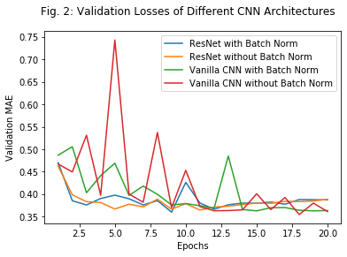

```python
fig, ax = plt.subplots()
test_loss_path  = "C:/Users/admin/Desktop/TF_Models/selfie_model/"
test_loss_files = ["selfie_losses_no_batch_norm.csv",
                   "selfie_losses_cnn_batch_norm.csv",
                   "selfie_losses_cnn_no_batch_norm_12_layers_16_filters.csv"]

ax.plot(train_progress["epoch"], train_progress["valid_mae"])
for test_loss_file in test_loss_files:
    test_loss_df = pd.read_csv(test_loss_path+test_loss_file)
    ax.plot(test_loss_df["epoch"], test_loss_df["valid_mae"])

ax.set(xlabel="Epochs", ylabel="Validation MAE")
ax.legend(["ResNet with Batch Norm",
           "ResNet without Batch Norm",
           "Vanilla CNN with Batch Norm",
           "Vanilla CNN without Batch Norm"])
fig.suptitle("Fig. 2: Validation Losses of Different CNN Architectures")
```

### Hyper-Parameter Tuning

In this section, the parameters of the CNN model are tuned to identify the "best" model among a pre-defined set of parameters. It is worth noting that the batch size of 32 may not be a suitably large number to compute the batch mean and variances upon, but did not perform any tuning on the batch size parameter. The parameters tuned include the number of filters (8 and 16) and the number of layers (12 and 18). Since the ablation study revealed that the best model is the vanilla CNN model without residual connections or batch normalisation, this model is used to perform hyper-parameter tuning. The results are presented in Table 2 and Fig. 3.

| Number of Layers | Number of Filters | Mean Absolute Error on Test Dataset |
| --- | --- | --- |
| 12 | 8 | 0.396 |
| 18 | 8 | 0.389 |
| 12 | 16 | 0.361 |
| 18 | 16 | 0.389 |

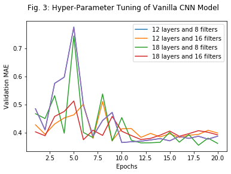

```python
num_layers  = [12, 18]
num_filters = [8, 16]
plot_legend = []

fig, ax = plt.subplots()
ax.plot(test_loss_df["epoch"], test_loss_df["valid_mae"])
for num_layer in num_layers:
    for num_filter in num_filters:
        test_loss_file = "selfie_losses_cnn_no_batch_norm_" +\
            str(num_layer) + "_layers_" + str(num_filter) + "_filters.csv"
        test_loss_df = pd.read_csv(test_loss_path+test_loss_file)
        ax.plot(test_loss_df["epoch"], test_loss_df["valid_mae"])
        plot_legend.append(str(num_layer) + " layers and " + str(num_filter) + " filters")

ax.set(xlabel="Epochs", ylabel="Validation MAE")
ax.legend(plot_legend)
fig.suptitle("Fig. 3: Hyper-Parameter Tuning of Vanilla CNN Model")
```

### Analysis of Results

```python
test_df = pd.read_csv(
    test_loss_path + "selfie_test_losses_" +\
    "cnn_no_batch_norm_12_layers_16_filters.csv")
test_df = test_df.merge(tmp_selfie_df, on="filename")
test_df["err"] = test_df["score"] - test_df["pred"]

print("Mean Absolute Error in Test Dataset:",
      str(np.mean(np.abs(test_df["err"].values))))
```

```
Mean Absolute Error in Test Dataset: 0.36127195403109646
```

```python
test_df[["filename", "pred", "score", "gender", "age_category"]].head()
```

[output not shown]

```python
# Group the errors by age. #
tmp_grp_age_test = pd.DataFrame(
    [(x, len(y), np.mean(np.abs(y["err"]))) for \
     x, y in test_df.groupby(["age_category"])],
    columns = ["age_category", "count", "mean_abs_error"])

# Display the results. #
tmp_grp_age_test.sort_values(["mean_abs_error"], ascending=True).head(7)
```

|  | age_category | count | mean_abs_error |
| --- | --- | --- | --- |
| 0 | baby | 21 | 0.343318 |
| 2 | middle_age | 119 | 0.358320 |
| 6 | youth | 3180 | 0.359644 |
| 4 | teenager | 627 | 0.361454 |
| 5 | unknown | 662 | 0.367100 |
| 1 | child | 74 | 0.382139 |
| 3 | senior | 1 | 0.750212 |

```python
# Group the errors by gender. #
tmp_grp_gender_test = pd.DataFrame(
    [(x, len(y), np.mean(np.abs(y["err"]))) \
     for x, y in test_df.groupby(["gender"])],
    columns = ["gender", "count", "mean_abs_error"])

# Display the results. #
tmp_grp_gender_test.sort_values(["mean_abs_error"], ascending=True).head()
```

|  | gender | count | mean_abs_error |
| --- | --- | --- | --- |
| 0 | female | 3374 | 0.360812 |
| 1 | male | 1310 | 0.362457 |

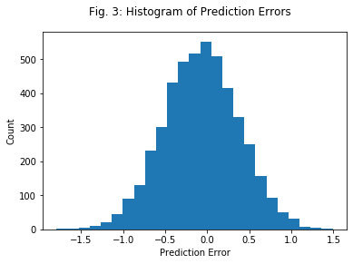

```python
fig, ax = plt.subplots()
ax.hist(test_df["err"], bins=25)
ax.set(xlabel="Prediction Error", ylabel="Count")
fig.suptitle("Fig. 3: Histogram of Prediction Errors")
```

A random sample (not cherry picked) of 4 test images and their corresponding errors are displayed below. As the left most image's attributes show, there may be erroneous labelling of some of the attributes. In this case, the left most image appeared to me to be more of a male than a female but it is tagged as a female. This might affect the analysis of the results.

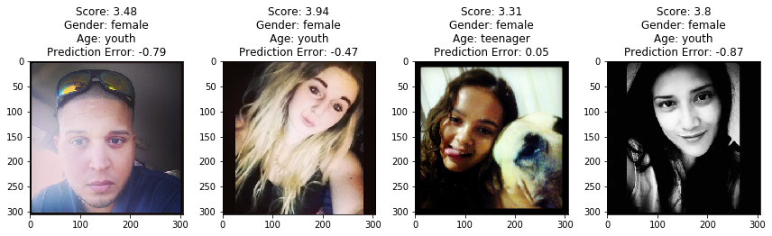

```python
# Randomly select a few images and their predicted scores to display. #
fig, ax = plt.subplots(ncols=4, figsize=(12, 12))

tmp_idx = np.random.choice(len(test_df), size=4, replace=False)
n_image = 0
for row in ax:
    tmp_row = test_df.iloc[tmp_idx[n_image]]
    tmp_img = mpimg.imread(tmp_row["filename"])
    n_image += 1

    tmp_title = "Score: " + str(round(tmp_row["score"], 2)) + "\n"
    tmp_title += "Gender: " + str(tmp_row["gender"]) + "\n"
    tmp_title += "Age: " + str(tmp_row["age_category"]) + "\n"
    tmp_title += "Prediction Error: " + str(round(tmp_row["err"], 2))
    row.imshow(tmp_img)
    row.set(title=tmp_title)
plt.tight_layout()
```

### Concluding Remarks

In this project, I trained a CNN model to predict the popularity score of a selfie taken. Although the data was imbalanced with more young people and females, the prediction errors between the under-represented classes was not observably different from that of the dominant classes. The different model architectures were analysed using ablation study, whereby the effects of Batch Normalisation and Residual Connections was presented. Perhaps surprisingly, the simpler model which applied neither Batch Normalisation nor Residual Connections had the best performance on the test dataset.

I also tested different model configurations using hyper-parameter tuning of the number of layers as well as the number of filters. Code can be found in `selfie_code.py`.